# Question 3 - WebText API Proof of Concept: Scrape, Preprocess, Summarise

## Packages

```r
# install.packages(c("tidyverse","tidytext","rvest","httr","robotstxt","xml2","textstem","igraph","wordcloud","RColorBrewer"))
library(tidyverse)
library(tidytext)
library(rvest)
library(httr)
library(robotstxt)
library(xml2)
library(textstem)
library(igraph)
library(wordcloud)
library(RColorBrewer)
set.seed(42)
```

## 3.1 Extract web content into an R data structure

### Site chosen and fair-use compliance

I selected the Eurac Research science blog (the article “Can language become environmental data?”), because the site states that its content is licensed under Creative Commons Attribution 4.0, which permits reuse with attribution. Fair-use / ethical scraping measures applied:

1. `robots.txt` is checked programmatically before any request.
2. A descriptive User-Agent is sent.
3. Requests are rate-limited (2 seconds apart) and only a handful of public pages are fetched.
4. Only public article text is collected, no personal data, for educational use, and the source is credited (Eurac Research, CC BY 4.0).

```r
START_URL     <- "https://www.eurac.edu/en/blogs/connecting-the-dots/can-language-become-environmental-data"
DISCOVER_MORE <- TRUE     # also scrape a few sibling blog posts for a richer corpus
MAX_EXTRA     <- 4
UA <- user_agent("ITBDA4-14 student coursework (text mining proof of concept)")

# robots.txt check
paths_allowed(START_URL, user_agent = "*")
```

```
## [1] TRUE
```

If `paths_allowed()` returns `FALSE`, stop and choose another site.

```r
scrape_page <- function(url) {
  Sys.sleep(2)                                   # polite delay
  resp <- GET(url, UA, timeout(20))
  stop_for_status(resp)
  page <- read_html(content(resp, "text", encoding = "UTF-8"))

  title <- page |> html_element("h1") |> html_text2()

  # try progressively broader selectors for the article body
  paras <- page |> html_elements("article p") |> html_text2()
  if (length(paras) < 3) paras <- page |> html_elements("main p") |> html_text2()
  if (length(paras) < 3) paras <- page |> html_elements("p") |> html_text2()

  tibble(url = url, title = title, para_id = seq_along(paras), text = paras)
}

urls <- START_URL

if (DISCOVER_MORE) {
  home <- read_html(content(GET(START_URL, UA), "text", encoding = "UTF-8"))
  more <- home |> html_elements("a") |> html_attr("href") |>
    url_absolute(START_URL) |>
    unique() |>
    keep(~ str_detect(.x, "/blogs/connecting-the-dots/") && .x != START_URL) |>
    head(MAX_EXTRA)
  urls <- c(urls, more)
}

raw_web <- map_dfr(urls, possibly(scrape_page, otherwise = NULL))
glimpse(raw_web)
```

```
## Rows: 24
## Columns: 4
## $ url     <chr> "https://www.eurac.edu/en/blogs/connecting-the-dots/can-langua…
## $ title   <chr> "Can language become environmental data?", "Can language becom…
## $ para_id <int> 1, 2, 3, 4, 5, 6, 7, 8, 9, 10, 11, 12, 1, 2, 3, 4, 5, 6, 7, 8,…
## $ text    <chr> "Language is messy, subjective, and influenced by the intentio…
```

```r
raw_web |> count(title)
```

```
## # A tibble: 1 × 2
##   title                                       n
##   <chr>                                   <int>
## 1 Can language become environmental data?    24
```

`raw_web` (one row per paragraph: `url`, `title`, `para_id`, `text`) is the R data structure used from here on.

## 3.2 Textual preprocessing

Steps: remove empty/very short paragraphs, remove site boilerplate (navigation, cookie, newsletter, social/footer text), remove duplicates, strip HTML remnants, URLs and e-mails, lower-case, remove digits and punctuation, remove stop words and short tokens, lemmatise.

```r
boilerplate <- regex(
  "cookie|newsletter|subscribe|follow us|share|privacy|imprint|work with us|get directions|creative commons|licensed under|access work|choose language|all rights reserved|data scientist working",
  ignore_case = TRUE)

web_clean <- raw_web |>
  mutate(text = str_squish(text)) |>
  filter(nchar(text) > 40,                          # drop menu items / captions
         !str_detect(text, boilerplate)) |>         # drop boilerplate
  distinct(text, .keep_all = TRUE)                  # drop duplicates

clean_text <- function(x) {
  x |>
    str_replace_all("<[^>]+>", " ") |>
    str_replace_all("http\\S+|www\\.\\S+", " ") |>
    str_replace_all("\\S+@\\S+", " ") |>
    str_to_lower() |>
    str_replace_all("[^a-z\\s]", " ") |>
    str_squish()
}

extra_stop <- c("also","can","may","might","one","two","use","used","using","like","et","al")

tokens <- web_clean |>
  mutate(clean = clean_text(text)) |>
  unnest_tokens(word, clean) |>
  filter(!word %in% stop_words$word, !word %in% extra_stop, nchar(word) > 2) |>
  mutate(word = lemmatize_words(word),
         word = if_else(word == "datum", "data", word)) |>
  filter(!word %in% stop_words$word)

cat("Paragraphs kept:", nrow(web_clean), "of", nrow(raw_web), "\n")
```

```
## Paragraphs kept: 9 of 24
```

```r
cat("Tokens:", nrow(tokens), " Unique terms:", n_distinct(tokens$word), "\n")
```

```
## Tokens: 334  Unique terms: 209
```

```r
head(tokens)
```

```
## # A tibble: 6 × 5
##   url                                                  title para_id text  word
##   <chr>                                                <chr>   <int> <chr> <chr>
## 1 https://www.eurac.edu/en/blogs/connecting-the-dots/… Can …       1 Lang… lang…
## 2 https://www.eurac.edu/en/blogs/connecting-the-dots/… Can …       1 Lang… messy
## 3 https://www.eurac.edu/en/blogs/connecting-the-dots/… Can …       1 Lang… subj…
## 4 https://www.eurac.edu/en/blogs/connecting-the-dots/… Can …       1 Lang… infl…
## 5 https://www.eurac.edu/en/blogs/connecting-the-dots/… Can …       1 Lang… inte…
## 6 https://www.eurac.edu/en/blogs/connecting-the-dots/… Can …       1 Lang… prod…
```

## 3.3 Text summarisation

Two extractive techniques are applied at sentence level:

- **Method 1 - Word-frequency scoring (Luhn style):** a sentence scores the sum of the normalised frequencies of its content words, divided by the square root of its length so long sentences are not favoured unfairly.
- **Method 2 - TextRank:** sentences are nodes in a graph, edges are TF-IDF cosine similarities, and PageRank identifies the most central sentences.

```r
sentences <- web_clean |>
  select(url, title, text) |>
  unnest_tokens(sentence, text, token = "sentences", to_lower = FALSE) |>
  filter(nchar(sentence) > 40) |>
  mutate(sent_id = row_number())

sent_tokens <- sentences |>
  mutate(clean = clean_text(sentence)) |>
  select(sent_id, clean) |>
  unnest_tokens(word, clean) |>
  filter(!word %in% stop_words$word, !word %in% extra_stop, nchar(word) > 2) |>
  mutate(word = lemmatize_words(word),
         word = if_else(word == "datum", "data", word))

N_SUM <- 5   # sentences in each summary
cat("Sentences:", nrow(sentences), "\n")
```

```
## Sentences: 27
```

### Method 1: word-frequency scoring

```r
word_w <- sent_tokens |> count(word, name = "n") |> mutate(w = n / max(n))

score_freq <- sent_tokens |>
  left_join(word_w, by = "word") |>
  group_by(sent_id) |>
  summarise(score = sum(w) / sqrt(n()), .groups = "drop") |>
  mutate(method = "Word frequency")

summary_freq <- score_freq |>
  slice_max(score, n = N_SUM, with_ties = FALSE) |>
  arrange(sent_id) |>
  left_join(sentences, by = "sent_id")

summary_freq$sentence
```

```
## [1] "Clearly, reading and making sense of thousands and thousands of articles mentioning drought in more or less explicit ways, is not efficient to analyse and correlate traditional data on droughts with the impacts mentioned in the texts."
## [2] "Also, language can be messy, subjective, and influenced by the intentions of those who produce it, it captures how environmental change is experienced, discussed, and interpreted by society, but it is rarely a neat source of information."
## [3] "Newspaper articles do not simply state that a drought caused a specific impact at a specific location and time."
## [4] "For this reason, the combination of modern language technologies and sectorial drought assessment can help to automatically identify and extract relevant information in the text such as when a drought occurred, what sectors it impacted and where these impacts were felt."
## [5] "By analysing a large collection of Italian newspaper articles, we use language technologies to identify where drought impacts occurred, which sectors were affected, and when these impacts took place, with the aim of creating an openly available and regularly updated dataset that can help res…
```

### Method 2: TextRank

```r
tfidf <- sent_tokens |>
  count(sent_id, word) |>
  bind_tf_idf(word, sent_id, n)

m <- tfidf |> cast_sparse(sent_id, word, tf_idf) |> as.matrix()
m <- m / pmax(sqrt(rowSums(m^2)), 1e-9)            # unit-length rows -> cosine
sim <- m %*% t(m)
diag(sim) <- 0

g  <- graph_from_adjacency_matrix(sim, mode = "undirected", weighted = TRUE)
pr <- page_rank(g)$vector

score_tr <- tibble(sent_id = as.integer(names(pr)), score = pr, method = "TextRank")

summary_tr <- score_tr |>
  slice_max(score, n = N_SUM, with_ties = FALSE) |>
  arrange(sent_id) |>
  left_join(sentences, by = "sent_id")

summary_tr$sentence
```

```
## [1] "Yet it also captures how environmental change is experienced, discussed, and interpreted by society."
## [2] "Together, these texts contain valuable information about how drought affects society and the environment."
## [3] "Also, language can be messy, subjective, and influenced by the intentions of those who produce it, it captures how environmental change is experienced, discussed, and interpreted by society, but it is rarely a neat source of information."
## [4] "For this reason, the combination of modern language technologies and sectorial drought assessment can help to automatically identify and extract relevant information in the text such as when a drought occurred, what sectors it impacted and where these impacts were felt."
## [5] "By analysing a large collection of Italian newspaper articles, we use language technologies to identify where drought impacts occurred, which sectors were affected, and when these impacts took place, with the aim of creating an openly available and regularly updated dataset that can help res…
```

Agreement between the two summaries:

```r
shared <- intersect(summary_freq$sent_id, summary_tr$sent_id)
cat("Sentences chosen by both methods:", length(shared), "of", N_SUM, "\n")
```

```
## Sentences chosen by both methods: 3 of 5
```

## Visualisations

**Visualisation 1 - most frequent content words**

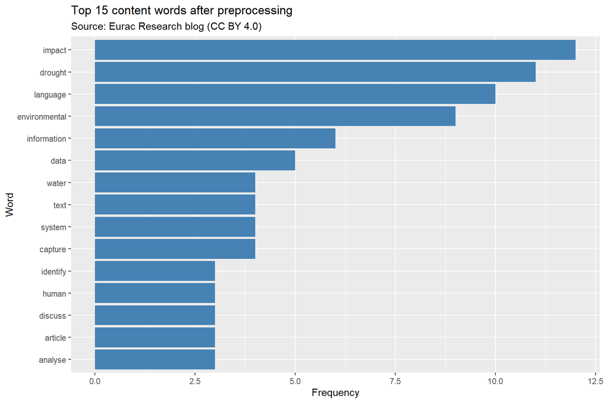

```r
tokens |>
  count(word, sort = TRUE) |>
  slice_max(n, n = 15, with_ties = FALSE) |>
  ggplot(aes(n, reorder(word, n))) +
  geom_col(fill = "steelblue") +
  labs(title = "Top 15 content words after preprocessing",
       subtitle = "Source: Eurac Research blog (CC BY 4.0)",
       x = "Frequency", y = "Word")
```

**Visualisation 2 - word cloud**

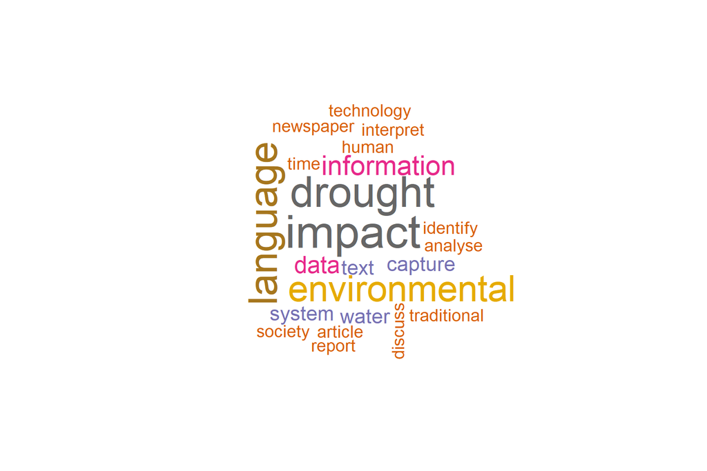

```r
wc <- count(tokens, word, sort = TRUE)
wordcloud(wc$word, wc$n, max.words = 80, scale = c(3.5, 0.6),
          colors = brewer.pal(8, "Dark2"), random.order = FALSE)
```

**Visualisation 3 - sentence scores selected by each summarisation method**

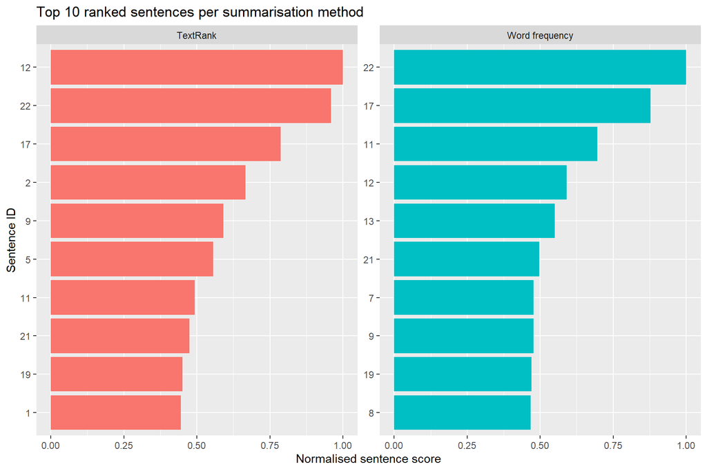

```r
bind_rows(score_freq, score_tr) |>
  group_by(method) |>
  mutate(score = score / max(score)) |>          # put both methods on a 0-1 scale
  slice_max(score, n = 10, with_ties = FALSE) |>
  ungroup() |>
  mutate(sent_id = reorder_within(factor(sent_id), score, method)) |>
  ggplot(aes(score, sent_id, fill = method)) +
  geom_col(show.legend = FALSE) +
  facet_wrap(~ method, scales = "free_y") +
  scale_y_reordered() +
  labs(title = "Top 10 ranked sentences per summarisation method",
       x = "Normalised sentence score", y = "Sentence ID")
```

**Visualisation 4 (bonus) - sentence similarity network (TextRank graph)**

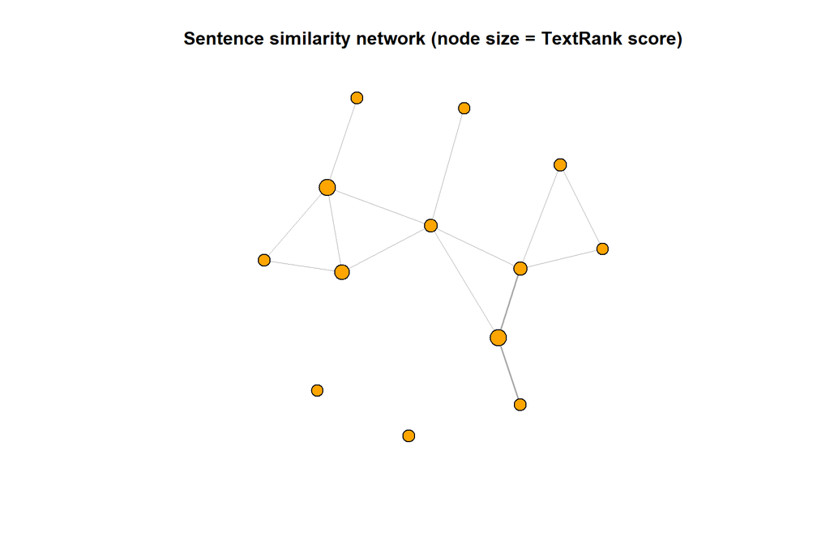

```r
keep <- which(strength(g) > quantile(strength(g), 0.5))
g_small <- induced_subgraph(g, keep)
E(g_small)$weight[E(g_small)$weight < 0.1] <- 0
g_small <- delete_edges(g_small, E(g_small)[weight == 0])
plot(g_small, vertex.size = 5 + 60 * pr[V(g_small)$name], vertex.label = NA,
     edge.width = 3 * E(g_small)$weight, vertex.color = "orange",
     main = "Sentence similarity network (node size = TextRank score)")
```

## Findings

Dominant words and theme. After preprocessing, the corpus contained 334 tokens and 209 unique terms from 9 retained paragraphs (27 sentences). The most frequent words were impact (12 occurrences), drought (11), language (10) and environmental (9), followed by information (6), data (5) and water, text, system and capture (4 each). These words show that the article is about using language technologies to extract information about drought impacts from text, treating how people write about environmental change as a data source that complements traditional measurements.

Limitations. The corpus is a single short article, so frequencies and graph structure rest on small counts. Both methods are extractive, so they can only copy existing sentences, some of which are long or lose context. Cleaning required judgement: an author byline initially passed the filters and was ranked as an important sentence by both methods until it was removed, and the lemmatiser changed “data” to “datum” until it was corrected. Scraping also depends on the page’s HTML structure, so a layout change could break extraction.

Towards a WebText API. Steps 3.1 to 3.3 can be wrapped into functions such as scrape_url(), clean_text() and summarise_text(), taking a link and returning the cleaned text, the top terms and an N-sentence summary. This is the proof of concept requested and could be deployed as a service (for example with the plumber package), so a user submits a URL and receives the insights.